# RUV_FF_vs_Mal_all_groups_Salmon

## 3.5 Reactome of downregulated genes

```
## wrong orderBy parameter; set to default `orderBy = "x"`
```

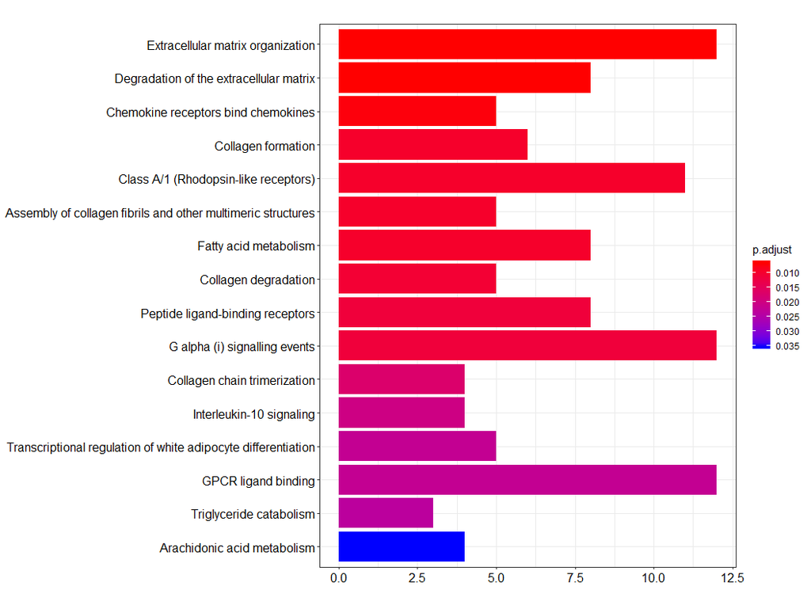

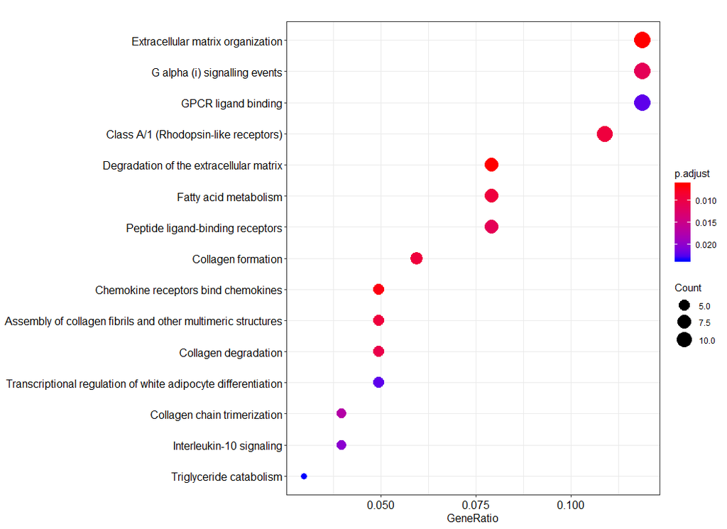

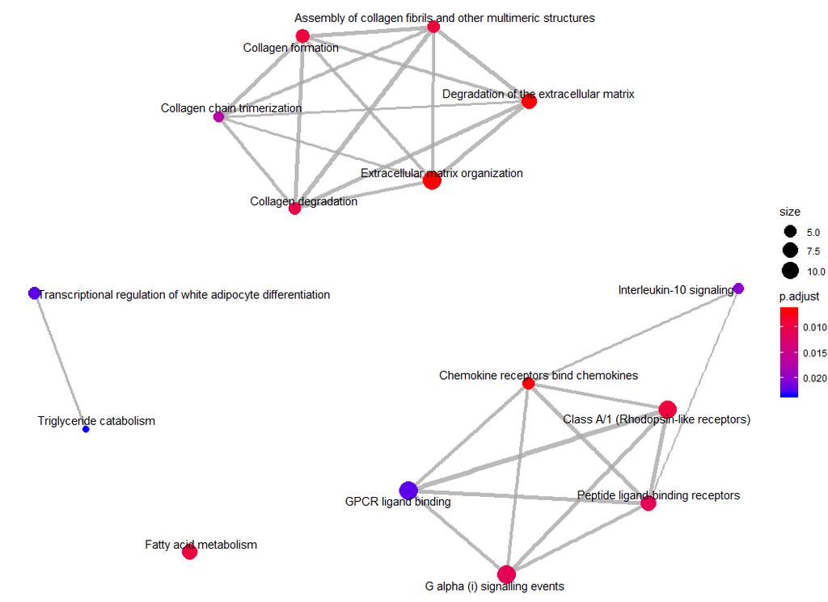

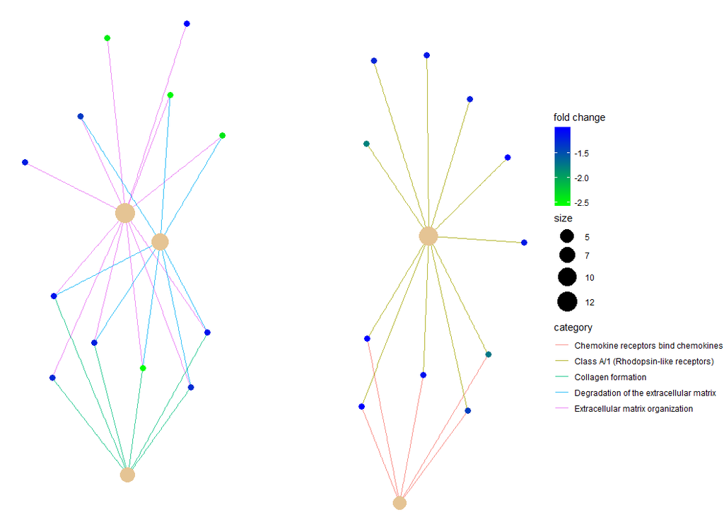

```r
if(!is.null(x)){
if(min(x@result$p.adjust)<0.05){
sprintf("Barplot for the most enriched reactome pathway for Salmon/DESeq analysis for comparison FF vs Mal all sections downregulated genes");
print(barplot(x, showCategory = 30));
sprintf("Dotplot for the most enriched reactome pathway for Salmon/DESeq analysis for comparison FF vs Mal all sections downregulated genes");
print(dotplot(x, showCategory = 15));
sprintf("Enrichment map plot for the most enriched reactome pathway for Salmon/DESeq analysis for comparison FF vs Mal all sections downregulated genes")
print(emapplot(x, showCategory = 15, color = "p.adjust",layout = "kk"));
print(cnetplot(x,showCategory = 5, categorySize = "pvalue", foldChange = down_genes_list, node_label= FALSE, colorEdge = TRUE));
}}
```

```r
y<- gsePathway(down_genes_list, nPerm = 1000,minGSSize = 10, pvalueCutoff = 0.05, pAdjustMethod = "BH")
```

```
## preparing geneSet collections...
```

```
## GSEA analysis...
```

```
## leading edge analysis...
```

```
## done...
```

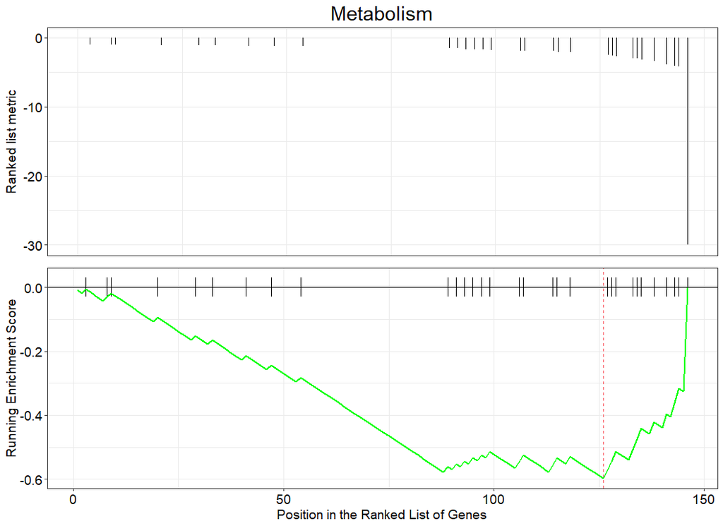

```
## Using `nicely` as default layout
```

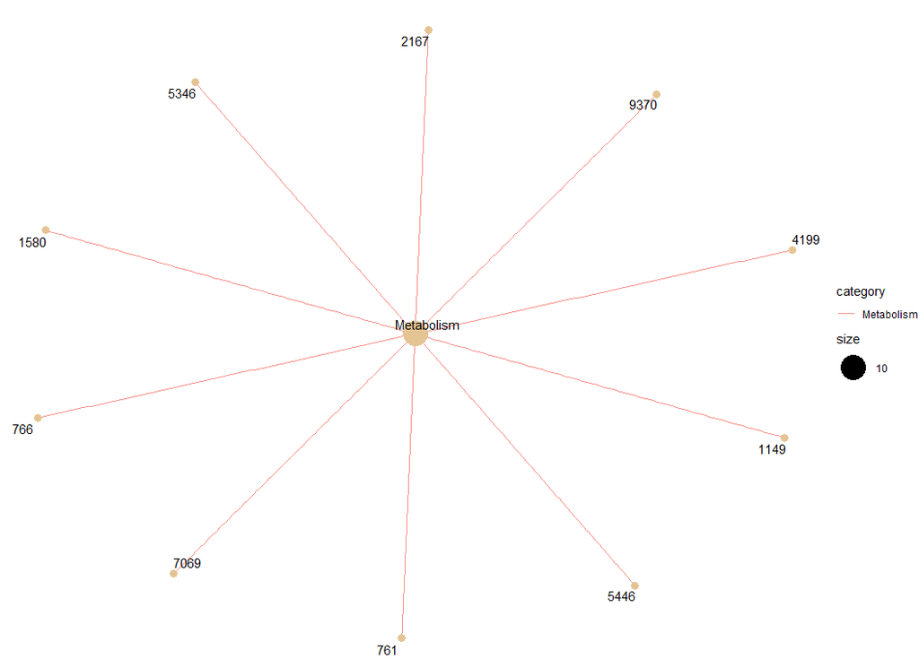

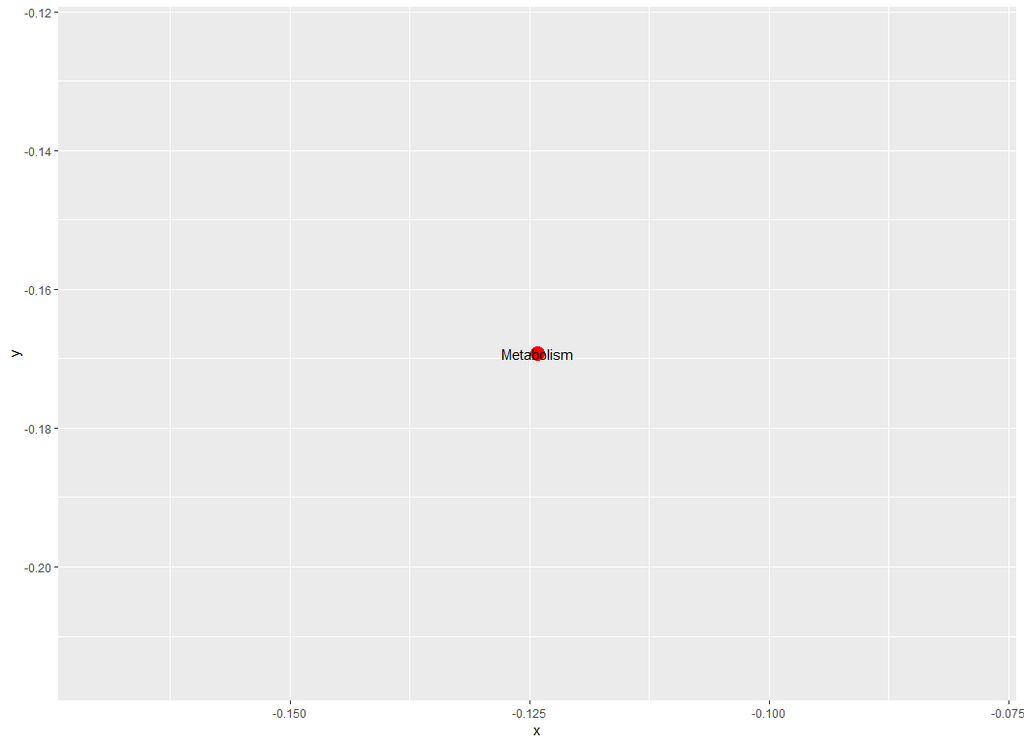

```r
if(nrow(y) > 0){
print(gseaplot(y, geneSetID =(as.data.frame(y))[1,1],title = as.character((as.data.frame(y))[1,2])));
print(cnetplot(y, categorySize = "pvalue", foldChange = downentrez$log2FoldChange,colorEdge = T));
print(emapplot(y, showCategory = 15, color = "p.adjust",layout = "kk"))
}
```

```r
#downunique<- down_genes_list[!duplicated(names(down_genes_list))]
#viewPathway(as.character((as.data.frame(y))[1,2]), readable = T, foldChange = downunique )
```

# 4 EdgeR analysis

We can repeat the same analysis using edgeR as the inference engine (Robinson, McCarthy, and Smyth 2009). The following code incorporates the average transcript length matrix as an offset for an edgeR analysis.

But I will use the tximport object to get the data to EdgeR, and normalize the data by the length of the transcript.

## 4.1 The results from the EdgeR

### 4.1.1 Counts of the EdgeRdataset

```r
head(as.data.frame(EdgeR_s$counts))
```

|  | FF1 | FF2 | FF3 | FF4 | FF5 | FF6 | FF7 | FF8 | FF9 | FF10 | FF11 | FF12 | Mal1 | Mal2 | Mal3 | Mal4 | Mal5 | Mal6 | Mal7 | Mal8 | Mal9 | Mal10 | Mal11 | Mal12 | Mal13 | Mal14 | Mal15 | Mal16 | Mal17 | … |
| --- | --- | --- | --- | --- | --- | --- | --- | --- | --- | --- | --- | --- | --- | --- | --- | --- | --- | --- | --- | --- | --- | --- | --- | --- | --- | --- | --- | --- | --- | --- |
| ENSSSCG00000000002 | 915.0468 | 2003.0845 | 529.0166 | 492.0342 | 847.0050 | 579.9999 | 583.0046 | 1010.000 | 715.0044 | 359.0002 | 1496.1259 | 579.9998 | 190.0003 | 1740.0039 | 283.0003 | 412.0425 | 2241.0622 | 405.9995 | 389.0024 | 2085.996 | 284.9998 | 504.0004 | 2413.056 | 1520.0150 | 186.000 | 2411.071 | 414.0059 | 413.0003 | 1705.017 | … |
| ENSSSCG00000000003 | 1285.9465 | 1761.3445 | 3665.4165 | 2501.8286 | 2027.7015 | 3743.1350 | 4098.0959 | 2527.166 | 6553.8731 | 3051.9850 | 2247.5235 | 5035.2613 | 5253.7460 | 3288.5607 | 5692.6060 | 5050.5516 | 2064.3780 | 6592.2290 | 2226.4200 | 2647.199 | 2990.3850 | 3578.3783 | 2533.195 | 2684.7247 | 3018.806 | 1848.915 | 3329.2840 | 5359.4435 | 3698.583 | … |
| ENSSSCG00000000005 | 144.0000 | 251.0000 | 268.0000 | 76.0000 | 215.0000 | 155.0000 | 155.0000 | 223.000 | 219.0000 | 69.0000 | 184.0000 | 206.0000 | 93.0000 | 238.0000 | 144.0000 | 135.0000 | 225.0000 | 153.0000 | 115.0000 | 340.000 | 144.0000 | 174.0000 | 329.000 | 305.0000 | 69.000 | 319.000 | 288.0000 | 219.0000 | 271.000 | … |
| ENSSSCG00000000006 | 63.0000 | 196.0000 | 138.0000 | 429.0000 | 415.0000 | 503.0000 | 786.0000 | 894.000 | 714.0000 | 772.0000 | 598.0000 | 622.0000 | 736.0000 | 594.0000 | 565.0000 | 769.0000 | 535.0000 | 683.0000 | 147.0000 | 338.000 | 197.0000 | 209.0000 | 345.000 | 63.0000 | 518.000 | 171.000 | 101.0000 | 535.0000 | 537.000 | … |
| ENSSSCG00000000007 | 300.0000 | 560.9999 | 502.0004 | 336.9997 | 371.0002 | 401.9995 | 479.0001 | 398.000 | 548.0004 | 386.0000 | 421.0003 | 445.0000 | 302.0000 | 531.0004 | 402.9999 | 515.0004 | 534.9999 | 372.0000 | 372.0000 | 516.000 | 348.9998 | 475.0000 | 583.000 | 546.9996 | 281.000 | 632.000 | 410.0000 | 434.9999 | 346.000 | … |
| ENSSSCG00000000010 | 752.7090 | 1310.9660 | 1708.7240 | 2926.3080 | 2958.9010 | 2512.2630 | 1617.8660 | 6242.510 | 1303.6550 | 2794.2020 | 1793.1000 | 2856.8670 | 1082.8860 | 1435.7780 | 855.9170 | 1858.9030 | 922.9770 | 2457.2530 | 693.9590 | 1384.558 | 1121.9830 | 3818.9100 | 2105.593 | 1773.8800 | 1629.245 | 1070.942 | 1235.2420 | 2532.3820 | 2525.892 | … |

### 4.1.2 MDS plot

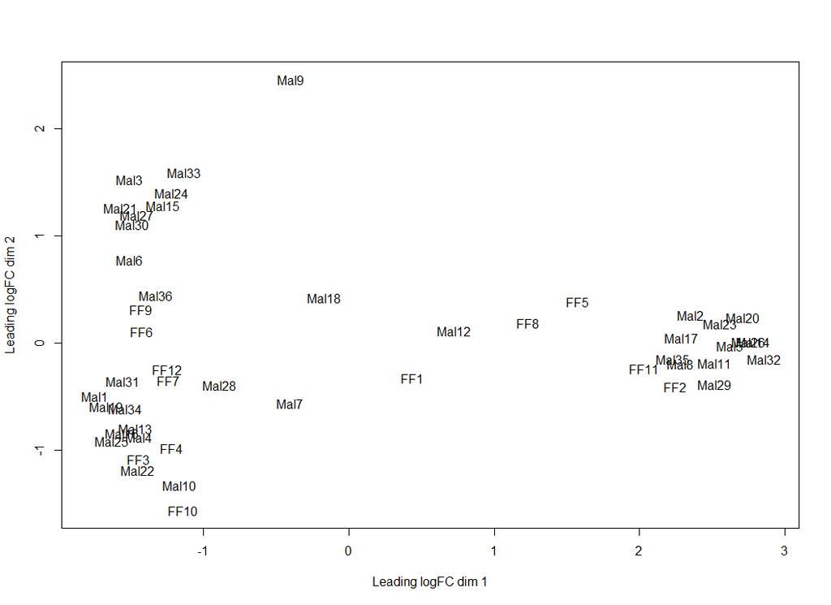

```r
plotMDS(EdgeR_s)
```

And the number of genes with pvalue < 0.1

```r
EdgeR_s$samples$W1<-set_n$W_1
design<-model.matrix(as.formula(~ W1+ group),data =EdgeR_s$samples)
DE_fit<-glmQLFit(EdgeR_s,design=design)
DE_single_factor_edgeR<- glmQLFTest(DE_fit)
sig_DE_EdgeR<-DE_single_factor_edgeR$table[DE_single_factor_edgeR$table$PValue < 0.1,]
dim(sig_DE_EdgeR)
```

[1] 4443 4

### 4.1.4 The toptags table for the sig. DE genes

Number of Genes with log2FoldChange < -1 or > 1, and p.adjusted < 0.1 and the table with the values.

```r
Topgenes_sfactor_edgeR<-topTags(DE_single_factor_edgeR, n = nrow(sig_DE_EdgeR))
dim(Topgenes_sfactor_edgeR)
```

[1] 4443 5

```r
#The FDR is adj. Pvalue
Topgenes_sfactor_edgeR_0.1_1<-
Topgenes_sfactor_edgeR[Topgenes_sfactor_edgeR$table$FDR < 0.1   & Topgenes_sfactor_edgeR$table$logFC < -1 | Topgenes_sfactor_edgeR$table$logFC > 1,]
dim(Topgenes_sfactor_edgeR_0.1_1)
```

[1] 206 5

```r
head(Topgenes_sfactor_edgeR_0.1_1$table)
```

|  | logFC | logCPM | F | PValue | FDR |
| --- | --- | --- | --- | --- | --- |
| ENSSSCG00000008959 | -1.723642 | 2.247362 | 112.07512 | 2.584000e-14 | 3.845250e-10 |
| ENSSSCG00000004454 | -2.535336 | 1.270901 | 97.79253 | 2.606689e-13 | 1.939507e-09 |
| ENSSSCG00000010554 | -2.048921 | 6.063951 | 81.36149 | 5.022607e-12 | 2.491380e-08 |
| ENSSSCG00000033822 | -3.329130 | 3.250774 | 78.44958 | 8.823927e-12 | 2.626177e-08 |
| ENSSSCG00000002009 | 1.268650 | 7.520116 | 75.27317 | 1.656468e-11 | 4.108316e-08 |
| ENSSSCG00000040681 | -3.002262 | 2.660089 | 73.57594 | 2.334839e-11 | 4.963534e-08 |

```r
Top_Genes_Table<-Topgenes_sfactor_edgeR_0.1_1$table[order(Topgenes_sfactor_edgeR_0.1_1$table$FDR),]
saveRDS(Top_Genes_Table, file = file.path(output_dir,sprintf("FF_vs_Mall_all_EdgeR_sig_Sal_w_outliers.RDS")))
```

## 4.2 Get the down regulated genes

```r
Topgenes_sfactor_edgeR_0.1_1_down<- Topgenes_sfactor_edgeR_0.1_1[Topgenes_sfactor_edgeR_0.1_1$table$logFC < 0, ]
Topgenes_sfactor_edgeR_0.1_1_down<- Topgenes_sfactor_edgeR_0.1_1_down[order(Topgenes_sfactor_edgeR_0.1_1_down$table$logFC), ]
head(Topgenes_sfactor_edgeR_0.1_1_down$table)
```

|  | logFC | logCPM | F | PValue | FDR |
| --- | --- | --- | --- | --- | --- |
| ENSSSCG00000039103 | -4.131247 | 3.945539 | 62.10837 | 2.717292e-10 | 5.054503e-07 |
| ENSSSCG00000001836 | -3.995404 | 2.134105 | 46.83573 | 1.104648e-08 | 5.668367e-06 |
| ENSSSCG00000006141 | -3.902337 | 1.842251 | 57.65967 | 7.554138e-10 | 6.920906e-07 |
| ENSSSCG00000033822 | -3.329130 | 3.250774 | 78.44958 | 8.823927e-12 | 2.626177e-08 |
| ENSSSCG00000035053 | -3.316462 | 4.124881 | 47.38508 | 9.569731e-09 | 5.085970e-06 |
| ENSSSCG00000038606 | -3.294792 | 3.363116 | 43.31117 | 2.832018e-08 | 1.201919e-05 |

```r
dim(Topgenes_sfactor_edgeR_0.1_1_down$table)
```

[1] 111 5

## 4.3 Getting the upregulated genes

```r
Topgenes_sfactor_edgeR_0.1_1_up<- Topgenes_sfactor_edgeR_0.1_1[Topgenes_sfactor_edgeR_0.1_1$table$logFC > 0, ]
Topgenes_sfactor_edgeR_0.1_1_up<-Topgenes_sfactor_edgeR_0.1_1_up[order(-Topgenes_sfactor_edgeR_0.1_1_up$table$logFC), ]
head(Topgenes_sfactor_edgeR_0.1_1_up$table)
```

|  | logFC | logCPM | F | PValue | FDR |
| --- | --- | --- | --- | --- | --- |
| ENSSSCG00000029592 | 2.719224 | 4.062941 | 52.75418 | 2.456809e-09 | 1.661808e-06 |
| ENSSSCG00000010488 | 2.593935 | 7.579872 | 17.87119 | 1.014894e-04 | 4.529296e-03 |
| ENSSSCG00000035347 | 2.373605 | 8.766003 | 54.46193 | 1.618988e-09 | 1.204608e-06 |
| ENSSSCG00000003006 | 2.279092 | 7.880709 | 19.52913 | 5.404233e-05 | 3.046227e-03 |
| ENSSSCG00000007507 | 2.278959 | 8.860372 | 58.29930 | 6.504095e-10 | 6.920906e-07 |
| ENSSSCG00000030694 | 2.248411 | 1.959071 | 14.71177 | 3.552471e-04 | 1.029593e-02 |

```r
dim(Topgenes_sfactor_edgeR_0.1_1_up$table)
```

[1] 95 5

## 4.4 Creating a volcano plot and a heatmap

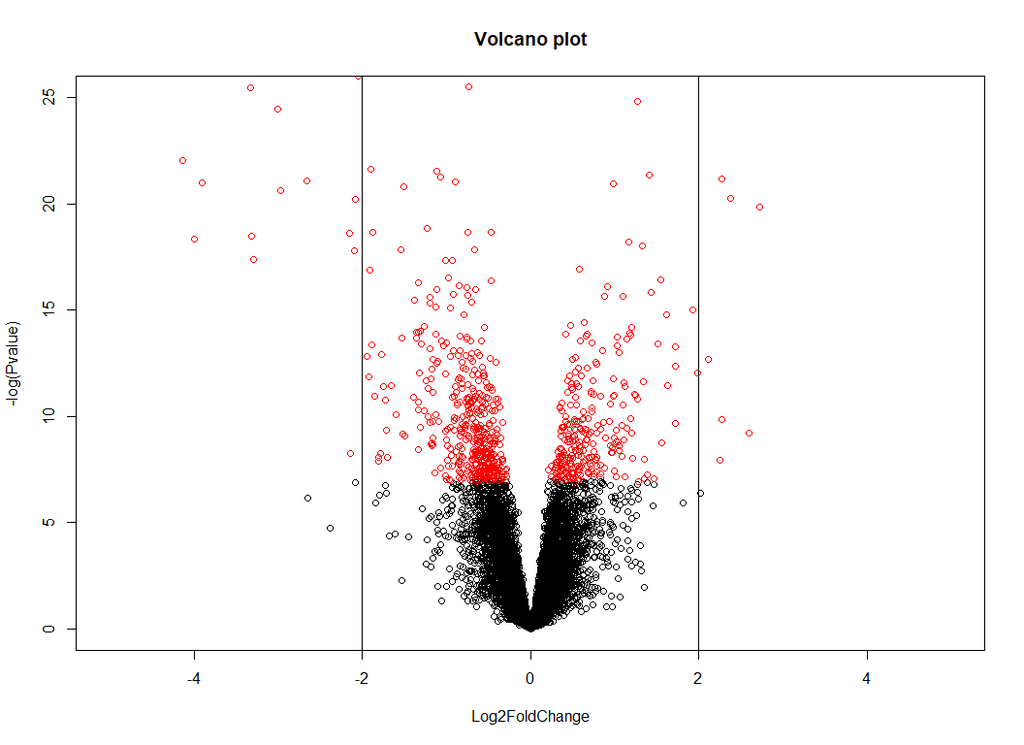

```r
plot(DE_single_factor_edgeR$table$logFC,-log(DE_single_factor_edgeR$table$PValue),main ="Volcano plot", xlab= "Log2FoldChange", ylab = "-log(Pvalue)", pch = 21, col=ifelse(DE_single_factor_edgeR$table$PValue<0.001,"red","black"), xlim= c(-5,5), ylim =c(0,25), abline(v=c(-2,2)))
```

```r
#Using normalized counts
counts_salmon_n <- cpm(EdgeR_s, normalized.lib.sizes = T)
Sig_counts<-counts_salmon_n[row.names(counts_salmon_n) %in% row.names(Topgenes_sfactor_edgeR_0.1_1$table),]
var_genes <- apply(Sig_counts, 1, var)
head(var_genes)
```

ENSSSCG00000000061 ENSSSCG00000000298 ENSSSCG00000000492 145.0515 1612.7227 1127626.6255 ENSSSCG00000000932 ENSSSCG00000000978 ENSSSCG00000001231 988.4352 53.8376 53921.2460

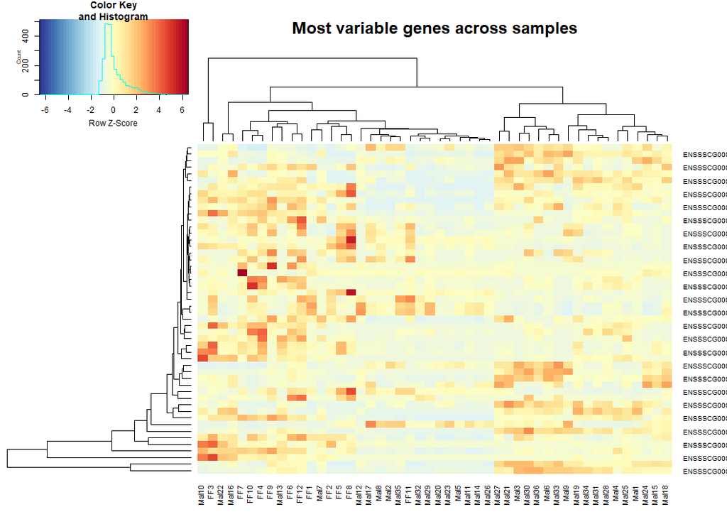

```r
Sig_counts<- cbind(Sig_counts, var_genes)
Sig_counts<-Sig_counts[order(Sig_counts[,7],decreasing =T),]
len<-ifelse(dim(Sig_counts)[1]<50, dim(Sig_counts)[1],50)
heatmap.2(Sig_counts[1:len,1:(ncol(Sig_counts)-1)],  trace="none",
              main="Most variable genes across samples", scale="row",col = rev(morecols(50)),
              labCol = labels )
```

## 4.5 Functional analysis of the EdgeR results

Using the DAVIDWEBServices to analize the DE genes and doing the plot2D of terms and evidence:

```r
if(is.connected(david)== FALSE) {
  connect(david)
}
DAVID_results_EdgeR<- addList(david, row.names(Topgenes_sfactor_edgeR_0.1_1$table), idType = "ENSEMBL_GENE_ID" , listName = sprintf("FF_vs_Mal_all_Sig_genes_EdgeR") ,listType = "Gene" )
# to see the p% of genes that were recognize on DAVID database
DAVID_results_EdgeR$inDavid
```

[1] 0.6213592

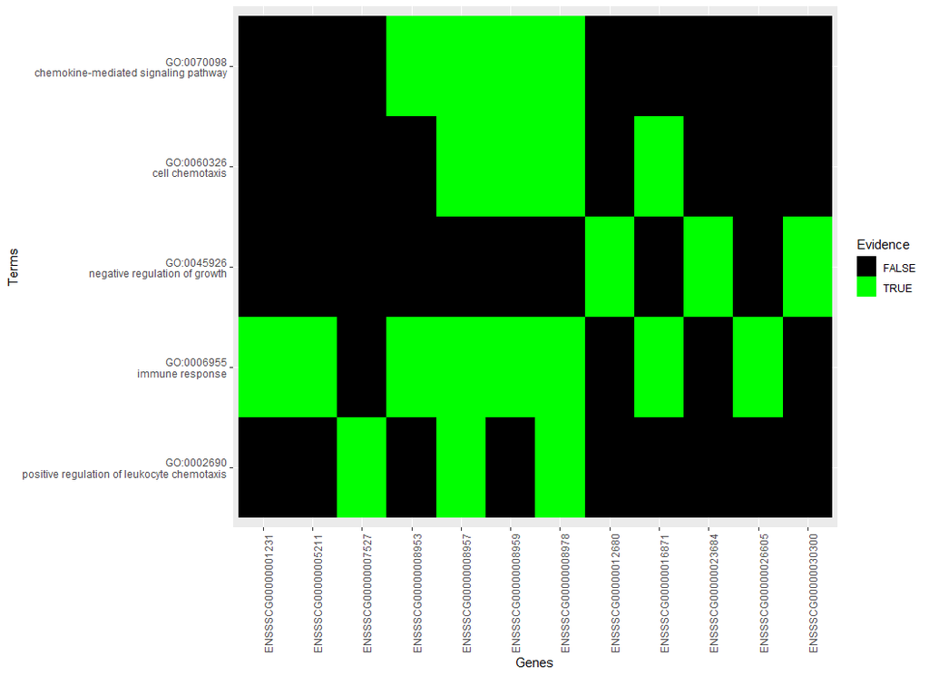

```r
DAVID_results_chart<- getFunctionalAnnotationChart(david)
DAVID_results_chart_EdgeR_BP<-DAVID_results_chart[DAVID_results_chart$Category == "GOTERM_BP_DIRECT" & DAVID_results_chart$PValue < 0.05,]
if(dim(DAVID_results_chart_EdgeR_BP)>0){
plot2D(DAVIDFunctionalAnnotationChart(DAVID_results_chart_EdgeR_BP[1:5,]),
       color=c("FALSE"="black", "TRUE"="green"))
}
```

# 5 Comparing the results from DESeq and EdgeR

```r
sprintf("DESeq2_FF_vs_all_Mal")
```

[1] “DESeq2_FF_vs_all_Mal”

```r
head(DAVID_results_chart_DESeq_BP[order(DAVID_results_chart_DESeq_BP$PValue),],10)
```

|  | Category | Term | Count | X. | PValue | Genes | List.Total | Pop.Hits | Pop.Total | Fold.Enrichment | Bonferroni | Benjamini | FDR |
| --- | --- | --- | --- | --- | --- | --- | --- | --- | --- | --- | --- | --- | --- |
| 12 | GOTERM_BP_DIRECT | GO:0006955~immune response | 11 | 5.3658537 | 0.0001297717 | ENSSSCG00000000482, ENSSSCG00000023737, ENSSSCG00000005211, ENSSSCG00000017044, ENSSSCG00000008978, ENSSSCG00000026605, ENSSSCG00000008959, ENSSSCG00000016871, ENSSSCG00000008957, ENSSSCG00000008953, … | 137 | 198 | 11368 | 4.609895 | 0.07611332 | 0.07611332 | 0.1919245 |
| 27 | GOTERM_BP_DIRECT | GO:0019373~epoxygenase P450 pathway | 3 | 1.4634146 | 0.0013876233 | ENSSSCG00000010546, ENSSSCG00000010488, ENSSSCG00000026798 | 137 | 5 | 11368 | 49.786861 | 0.57131720 | 0.34526127 | 2.0344959 |
| 29 | GOTERM_BP_DIRECT | GO:0045926~negative regulation of growth | 3 | 1.4634146 | 0.0020651209 | ENSSSCG00000023684, ENSSSCG00000030300, ENSSSCG00000012680 | 137 | 6 | 11368 | 41.489051 | 0.71663694 | 0.34317792 | 3.0137406 |
| 40 | GOTERM_BP_DIRECT | GO:0055114~oxidation-reduction process | 7 | 3.4146341 | 0.0060079903 | ENSSSCG00000009805, ENSSSCG00000017755, ENSSSCG00000010591, ENSSSCG00000004678, ENSSSCG00000026798, ENSSSCG00000004454, ENSSSCG00000010554 | 137 | 137 | 11368 | 4.239757 | 0.97467410 | 0.60107502 | 8.5339589 |
| 46 | GOTERM_BP_DIRECT | GO:0070098~chemokine-mediated signaling pathway | 4 | 1.9512195 | 0.0096703375 | ENSSSCG00000008978, ENSSSCG00000008959, ENSSSCG00000008957, ENSSSCG00000008953 | 137 | 37 | 11368 | 8.970606 | 0.99733517 | 0.69441358 | 13.3976528 |
| 47 | GOTERM_BP_DIRECT | GO:0002690~positive regulation of leukocyte chemotaxis | 3 | 1.4634146 | 0.0101652332 | ENSSSCG00000008978, ENSSSCG00000007527, ENSSSCG00000008957 | 137 | 13 | 11368 | 19.148793 | 0.99803551 | 0.64610462 | 14.0360719 |
| 60 | GOTERM_BP_DIRECT | GO:0050829~defense response to Gram-negative bacterium | 3 | 1.4634146 | 0.0234478921 | ENSSSCG00000017044, ENSSSCG00000026605, ENSSSCG00000000492 | 137 | 20 | 11368 | 12.446715 | 0.99999948 | 0.87351774 | 29.6174622 |
| 61 | GOTERM_BP_DIRECT | GO:0007274~neuromuscular synaptic transmission | 3 | 1.4634146 | 0.0234478921 | ENSSSCG00000007231, ENSSSCG00000029468, ENSSSCG00000009665 | 137 | 20 | 11368 | 12.446715 | 0.99999948 | 0.87351774 | 29.6174622 |
| 66 | GOTERM_BP_DIRECT | GO:0061402~positive regulation of transcription from RNA polymerase II promoter in response to acidic pH | 2 | 0.9756098 | 0.0237847289 | ENSSSCG00000011397, ENSSSCG00000007507 | 137 | 2 | 11368 | 82.978102 | 0.99999958 | 0.84046654 | 29.9759670 |
| 67 | GOTERM_BP_DIRECT | GO:0051365~cellular response to potassium ion starvation | 2 | 0.9756098 | 0.0237847289 | ENSSSCG00000011397, ENSSSCG00000007507 | 137 | 2 | 11368 | 82.978102 | 0.99999958 | 0.84046654 | 29.9759670 |

```r
sprintf("EdgeR_FF_vs_all_Mal")
```

[1] “EdgeR_FF_vs_all_Mal”

```r
head(DAVID_results_chart_EdgeR_BP[order(DAVID_results_chart_EdgeR_BP$PValue),],10)
```

|  | Category | Term | Count | X. | PValue | Genes | List.Total | Pop.Hits | Pop.Total | Fold.Enrichment | Bonferroni | Benjamini | FDR |
| --- | --- | --- | --- | --- | --- | --- | --- | --- | --- | --- | --- | --- | --- |
| 14 | GOTERM_BP_DIRECT | GO:0006955~immune response | 8 | 6.25000 | 0.0005935698 | ENSSSCG00000005211, ENSSSCG00000008978, ENSSSCG00000026605, ENSSSCG00000008959, ENSSSCG00000016871, ENSSSCG00000008957, ENSSSCG00000008953, ENSSSCG00000001231 | 84 | 198 | 11368 | 5.468013 | 0.2128053 | 0.2128053 | 0.8256337 |
| 15 | GOTERM_BP_DIRECT | GO:0045926~negative regulation of growth | 3 | 2.34375 | 0.0007751520 | ENSSSCG00000023684, ENSSSCG00000030300, ENSSSCG00000012680 | 84 | 6 | 11368 | 67.666667 | 0.2683898 | 0.1446578 | 1.0769409 |
| 19 | GOTERM_BP_DIRECT | GO:0070098~chemokine-mediated signaling pathway | 4 | 3.12500 | 0.0024382190 | ENSSSCG00000008978, ENSSSCG00000008959, ENSSSCG00000008957, ENSSSCG00000008953 | 84 | 37 | 11368 | 14.630631 | 0.6261132 | 0.2795895 | 3.3512558 |
| 23 | GOTERM_BP_DIRECT | GO:0002690~positive regulation of leukocyte chemotaxis | 3 | 2.34375 | 0.0038991200 | ENSSSCG00000008978, ENSSSCG00000007527, ENSSSCG00000008957 | 84 | 13 | 11368 | 31.230769 | 0.7928717 | 0.3253790 | 5.3089509 |
| 28 | GOTERM_BP_DIRECT | GO:0060326~cell chemotaxis | 4 | 3.12500 | 0.0067611193 | ENSSSCG00000008978, ENSSSCG00000008959, ENSSSCG00000016871, ENSSSCG00000008957 | 84 | 53 | 11368 | 10.213836 | 0.9350400 | 0.4211991 | 9.0379341 |
| 32 | GOTERM_BP_DIRECT | GO:0042127~regulation of cell proliferation | 5 | 3.90625 | 0.0111186309 | ENSSSCG00000008978, ENSSSCG00000017755, ENSSSCG00000008959, ENSSSCG00000008957, ENSSSCG00000008953 | 84 | 119 | 11368 | 5.686275 | 0.9889564 | 0.5280981 | 14.4544745 |
| 33 | GOTERM_BP_DIRECT | GO:0051365~cellular response to potassium ion starvation | 2 | 1.56250 | 0.0145497228 | ENSSSCG00000011397, ENSSSCG00000007507 | 84 | 2 | 11368 | 135.333333 | 0.9972786 | 0.5699277 | 18.5070372 |
| 34 | GOTERM_BP_DIRECT | GO:0061402~positive regulation of transcription from RNA polymerase II promoter in response to acidic pH | 2 | 1.56250 | 0.0145497228 | ENSSSCG00000011397, ENSSSCG00000007507 | 84 | 2 | 11368 | 135.333333 | 0.9972786 | 0.5699277 | 18.5070372 |
| 42 | GOTERM_BP_DIRECT | GO:0032496~response to lipopolysaccharide | 4 | 3.12500 | 0.0161780660 | ENSSSCG00000008978, ENSSSCG00000008959, ENSSSCG00000008957, ENSSSCG00000008953 | 84 | 73 | 11368 | 7.415525 | 0.9986025 | 0.5602876 | 20.3672878 |
| 56 | GOTERM_BP_DIRECT | GO:0045124~regulation of bone resorption | 2 | 1.56250 | 0.0359830236 | ENSSSCG00000015334, ENSSSCG00000004157 | 84 | 5 | 11368 | 54.133333 | 0.9999996 | 0.8062028 | 40.0525335 |

```r
# We can see the top 5 GO pathways for biological process, and note how the evidence is true in our data for each of the genes in the pathway( if it is present on our sample or not)
#We can also use the chart to do a godag plot
```